# Lab 4: Determinantal and Gibbs models – solution

```r
library(spatstat)
```

### Exercise 1

In this question we fit a Strauss point process model to the `swedishpines` data.

1. We need a guess at the interaction distance $R$. Compute and plot the $K$-function of the dataset and choose the value $r$ which maximises the discrepancy $|K(r)-\pi r^2|$.

   We plot the above function which we want to maximize.

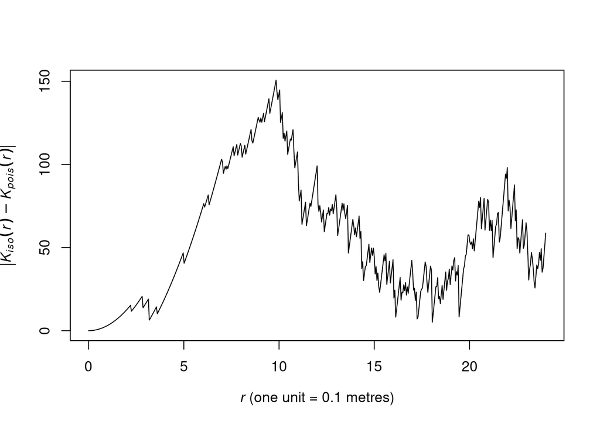

   ```r
   plot(Kest(swedishpines), abs(iso - theo) ~ r, main = "")
   ```

   ```r
   discrep <- function(r) {
     return(abs(as.function(Kest(swedishpines))(r) - pi*r^2))
   }
   res <- optimise(discrep, interval = c(0.1, 20), maximum = TRUE)
   print(res)
   ```

   ```
   ## $maximum
   ## [1] 9.84372
   ##
   ## $objective
   ## [1] 150.6897
   ```

   ```r
   R <- res$maximum
   ```

   This corresponds nicely with the plot.
2. Fit the stationary Strauss model with the chosen interaction distance using

   ```r
   ppm(swedishpines ~ 1, Strauss(R))
   ```

   where `R` is your chosen value.

   As we have assigned `R`, we simply write:

   ```r
   fit <- ppm(swedishpines ~ 1, Strauss(R))
   ```

3. Interpret the printout: how strong is the interaction?

   ```r
   print(fit)
   ```

   ```
   ## Stationary Strauss process
   ##
   ## First order term:  beta = 0.08310951
   ##
   ## Interaction distance:    9.84372
   ## Fitted interaction parameter gamma:  0.2407279
   ##
   ## Relevant coefficients:
   ## Interaction
   ##   -1.424088
   ##
   ## For standard errors, type coef(summary(x))
   ```

   The pairwise interaction function become:

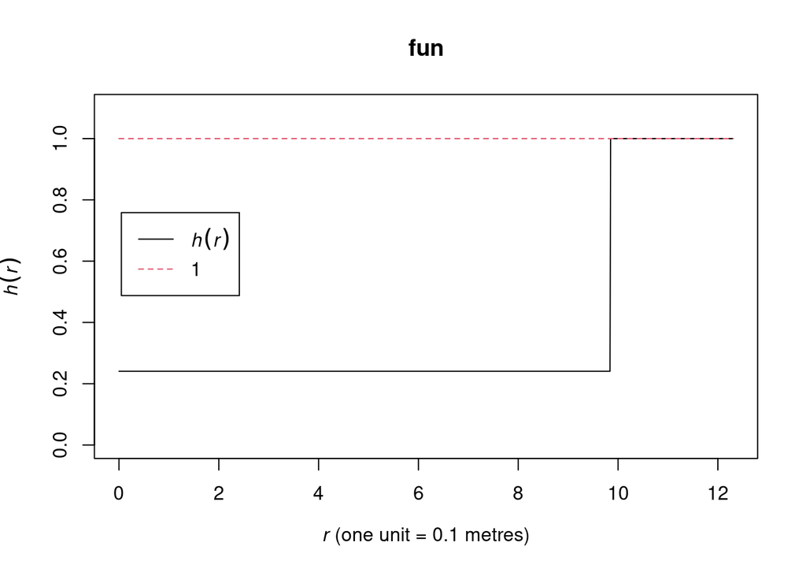

   ```r
   plot(fitin(fit))
   ```

### Exercise 2

In Question 1 we guesstimated the Strauss interaction distance parameter. Alternatively this parameter could be estimated by profile pseudolikelihood.

1. Look again at the plot of the $K$-function of `swedishpines` and determine a plausible range of possible values for the interaction distance.

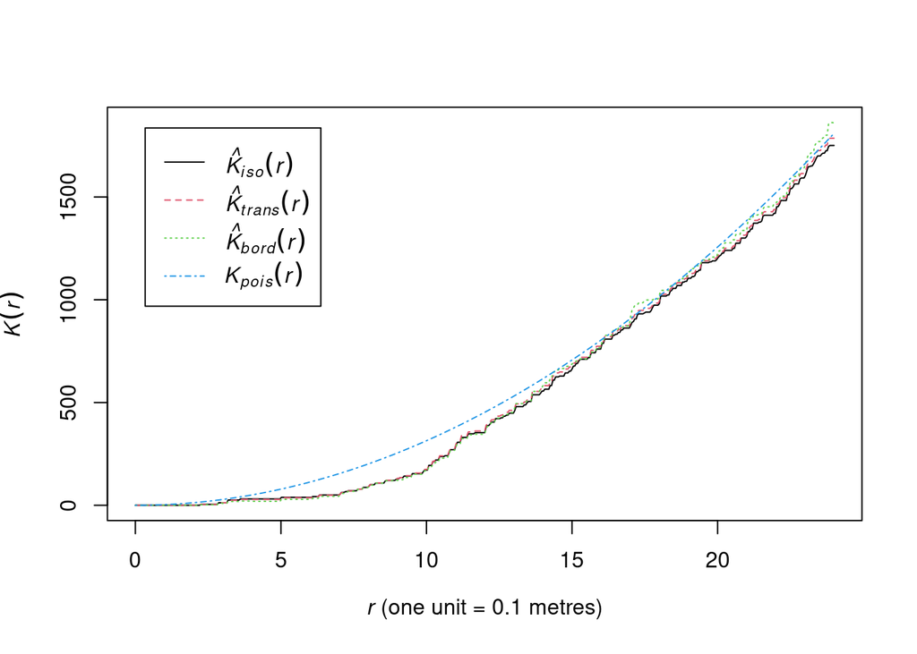

   ```r
   plot(Kest(swedishpines), main = "")
   ```

   ```r
   rvals <- seq(0.05, 0.3, by=0.01)
   ```

   We generate the numbers between 5 and 12.

   ```r
   rvals <- seq(5, 12, by = 0.1)
   ```

3. Construct a data frame, with one column named `r` (matching the argument name of `Strauss`), containing these values. For example

   ```r
   D <- data.frame(r = rvals)
   ```

   OK,

   ```r
   D <- data.frame(r = rvals)
   ```

4. Execute

   ```r
   fitp <- profilepl(D, Strauss, swedishpines ~ 1)
   ```

   to find the maximum profile pseudolikelihood fit.

   OK, let’s execute it:

   ```r
   fitp <- profilepl(D, Strauss, swedishpines ~ 1)
   ```

   ```
   ## (computing rbord)
   ```

   ```
   ## comparing 71 models...
   ```

   ```
   ## 1, 2, 3, 4, 5, 6, 7, 8, 9, 10, 11, 12, 13, 14, 15, 16, 17, 18, 19, 20, 21, 22, 23, 24, 25, 26, 27, 28, 29, 30, 31, 32, 33, 34, 35, 36, 37, 38, 39, 40,
   ## 41, 42, 43, 44, 45, 46, 47, 48, 49, 50, 51, 52, 53, 54, 55, 56, 57, 58, 59, 60, 61, 62, 63, 64, 65, 66, 67, 68, 69, 70,  71.
   ```

   ```
   ## fitting optimal model...
   ```

   ```
   ## done.
   ```

5. Print and plot the object `fitp`.

   ```r
   print(fitp)
   ```

   ```
   ## profile log pseudolikelihood
   ## for model:  ppm(swedishpines ~ 1,  interaction = Strauss)
   ## fitted with rbord = 12
   ## interaction: Strauss process
   ## irregular parameter: r in [5, 12]
   ## optimum value of irregular parameter:  r = 9.8
   ```

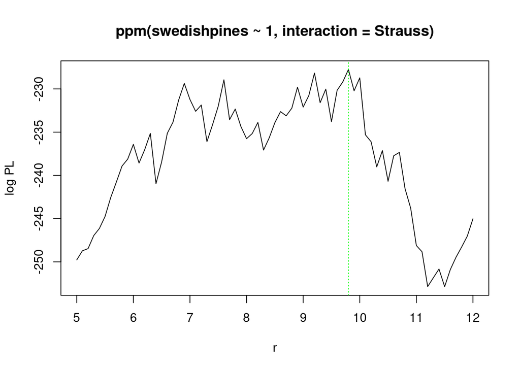

   ```r
   plot(fitp)
   ```

6. Compare the computed estimate of interaction distance $r$ with your guesstimate. Compare the corresponding estimates of the Strauss interaction parameter $\gamma$.

   ```r
   (Ropt <- reach(as.ppm(fitp)))
   ```

   ```
   ## [1] 9.8
   ```

   The $r = 9.8$ is consistent with the previous guesstimate.
7. Extract the fitted Gibbs point process model from the object `fitp` as

   ```r
   bestfit <- as.ppm(fitp)
   ```

   OK, let’s do that:

   ```r
   bestfit <- as.ppm(fitp)
   ```

### Exercise 3

Modify Question 1 by using the Huang-Ogata approximate maximum likelihood algorithm (`method="ho"`) instead of maximum pseudolikelihood (the default, `method="mpl"`).

```r
fit.mpl <- ppm(swedishpines ~ 1, Strauss(R), method = "mpl")
fit.ho  <- ppm(swedishpines ~ 1, Strauss(R), method = "ho")
```

```
## Simulating... 1, 2, 3, 4, 5, 6, 7, 8, 9, 10, 11, 12, 13, 14, 15, 16, 17, 18, 19, 20, 21, 22, 23, 24, 25, 26, 27, 28, 29, 30, 31, 32, 33, 34, 35, 36, 37, 38, 39, 40,
## 41, 42, 43, 44, 45, 46, 47, 48, 49, 50, 51, 52, 53, 54, 55, 56, 57, 58, 59, 60, 61, 62, 63, 64, 65, 66, 67, 68, 69, 70, 71, 72, 73, 74, 75, 76, 77, 78, 79, 80,
## 81, 82, 83, 84, 85, 86, 87, 88, 89, 90, 91, 92, 93, 94, 95, 96, 97, 98, 99,  100.
## Done.
```

```r
print(fit.ho)
```

```
## Stationary Strauss process
##
## First order term:  beta = 0.1126732
##
## Interaction distance:    9.84372
## Fitted interaction parameter gamma:  0.2257317
##
## Relevant coefficients:
## Interaction
##   -1.488408
##
## For standard errors, type coef(summary(x))
```

```r
print(fit.mpl)
```

```
## Stationary Strauss process
##
## First order term:  beta = 0.08310951
##
## Interaction distance:    9.84372
## Fitted interaction parameter gamma:  0.2407279
##
## Relevant coefficients:
## Interaction
##   -1.424088
##
## For standard errors, type coef(summary(x))
```

The fits are very similar.

### Exercise 4

Repeat Question 2 for the inhomogeneous Strauss process with log-quadratic trend. The corresponding call to `profilepl` is

```r
fitp <- profilepl(D, Strauss, swedishpines ~ polynom(x,y,2))
```

```
## (computing rbord)
```

```
## comparing 71 models...
```

```
## 1, 2, 3, 4, 5, 6, 7, 8, 9, 10, 11, 12, 13, 14, 15, 16, 17, 18, 19, 20, 21, 22, 23, 24, 25, 26, 27, 28, 29, 30, 31, 32, 33, 34, 35, 36, 37, 38, 39, 40,
## 41, 42, 43, 44, 45, 46, 47, 48, 49, 50, 51, 52, 53, 54, 55, 56, 57, 58, 59, 60, 61, 62, 63, 64, 65, 66, 67, 68, 69, 70,  71.
```

```
## fitting optimal model...
```

```
## done.
```

```r
fitp2 <- profilepl(D, Strauss, swedishpines ~ polynom(x,y,2))
```

```
## (computing rbord)
```

```
## comparing 71 models...
```

```
## 1, 2, 3, 4, 5, 6, 7, 8, 9, 10, 11, 12, 13, 14, 15, 16, 17, 18, 19, 20, 21, 22, 23, 24, 25, 26, 27, 28, 29, 30, 31, 32, 33, 34, 35, 36, 37, 38, 39, 40,
## 41, 42, 43, 44, 45, 46, 47, 48, 49, 50, 51, 52, 53, 54, 55, 56, 57, 58, 59, 60, 61, 62, 63, 64, 65, 66, 67, 68, 69, 70,  71.
```

```
## fitting optimal model...
```

```
## done.
```

```r
print(fitp2)
```

```
## profile log pseudolikelihood
## for model:  ppm(swedishpines ~ polynom(x,  y,  2),  interaction = Strauss)
## fitted with rbord = 12
## interaction: Strauss process
## irregular parameter: r in [5, 12]
## optimum value of irregular parameter:  r = 9.8
```

```r
(bestfit <- as.ppm(fitp2))
```

```
## Nonstationary Strauss process
##
## Log trend:  ~x + y + I(x^2) + I(x * y) + I(y^2)
##
## Fitted trend coefficients:
##   (Intercept)             x             y        I(x^2)      I(x * y)
## -5.156605e+00  4.269469e-02  8.582459e-02 -5.324026e-06 -7.955428e-04
##        I(y^2)
## -5.506409e-04
##
## Interaction distance:    9.8
## Fitted interaction parameter gamma:  0.2390264
##
## Relevant coefficients:
## Interaction
##   -1.431181
##
## For standard errors, type coef(summary(x))
```

```r
reach(bestfit)
```

```
## [1] 9.8
```

### Exercise 5

- Fit a stationary Gaussian DPP model to the `swedishpines` data using the `dppm()` command.

```r
fit <- dppm(swedishpines, dppGauss())
```

- Generate 39 simulations of the fitted model (simulations may take some time to generate).

```r
sim <- simulate(fit, nsim = 39)
```

- Make pointwise envelopes for a summary statistic of your choice (e.g. `Kest()`) using the generated 39 simulations (see the `simulate` argument in `envelope.ppp()`)

```r
env <- envelope(swedishpines, Lest, simulate = sim, nsim = 39)
```

```
## Extracting 39 point patterns from list  ...
## 1, 2, 3, 4, 5, 6, 7, 8, 9, 10, 11, 12, 13, 14, 15, 16, 17, 18, 19, 20, 21, 22, 23, 24, 25, 26, 27, 28, 29, 30, 31, 32, 33, 34, 35, 36, 37, 38,  39.
##
## Done.
```

- Plot the envelopes and consider whether you find the fitted model to be reasonable.

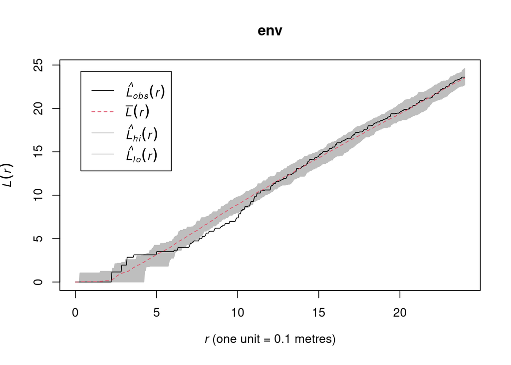

```r
plot(env)
```